# Configuración de VSCode con Python

La siguiente es una guía para configurar python en Visual Studio Code.

[TOC]

## Instalación de Python en Windows

Busque en su navegador de preferencia `Python`.

[figure not shown]

VSCode_Python

Dirijase a la pestaña de `Descargas` o `Downloads`.

[figure not shown]

VSCode_Python

Descargue el instalador de la última versión estable que esté disponible.

[figure not shown]

VSCode_Python

Ejecute el archivo de instalación y siga los pasos. Es indispensable que seleccione la casilla `Add python.exe to PATH` para que en las ventanas de terminal (Powershell o cmd) se pueda ejecutar código python.

[figure not shown]

VSCode_Python

Presione sobre la opción `Disable path length limit` y otorgue los permisos. Finalmente, cierre la ventana. Ha finalizado la instalación de python en Windows.

[figure not shown]

VSCode_Python

## Instalación de Visual Studio Code

Busque en su navegador de preferencia `Visual Studio Code`.

[figure not shown]

VSCode_Python

Dirijase a la pestaña de `Descargas` o `Downloads` y descargue el instalador. Una vez finalizada la descarga, ejecute el archivo.

[figure not shown]

VSCode_Python

Se desplegará la siguiente ventana, marque `Acepte el acuerdo de licencia` y presione en `Siguiente`.

[figure not shown]

VSCode_Python

En la siguiente ventana se indica el lugar de instalación. Se sugiere no modificar la ruta. Presione `Siguiente`.

[figure not shown]

VSCode_Python

Presione `Siguiente`.

[figure not shown]

VSCode_Python

Marque las casillas como se indica en la siguiente imagen.

[figure not shown]

VSCode_Python

Presione `Install` para iniciar el proceso de instalación.

[figure not shown]

VSCode_Python

Una vez ha finalizada la instalación, presione `Finish`.

[figure not shown]

VSCode_Python

## Configuración VSCode

En la primera ejecución, usted verá la siguiente ventana de inicio en donde podrá ajustar el estilo de visaulización dentro del entorno.

[figure not shown]

VSCode_Python

Dirijase a la pestaña de `Estensiones` y busque `Python`. Presione sobre el boton de `Instalar`.

[figure not shown]

VSCode_Python

## Probar configuración.

Los siguientes pasos se realizarán para comprobar el correcto funcionamiento en la configuración de VSCode con Python.

[figure not shown]

VSCode_Python

[figure not shown]

VSCode_Python

En la ventana que se despliega, presione sobre `Si, confío en los autores`.

[figure not shown]

VSCode_Python

En la herarquía de proyecto, encontrará los archivos de esa carpeta. Presione sobre `Nuevo archivo`, y asignele el nombre `main.py`.

[figure not shown]

VSCode_Python

```python
print("Hello World")
```

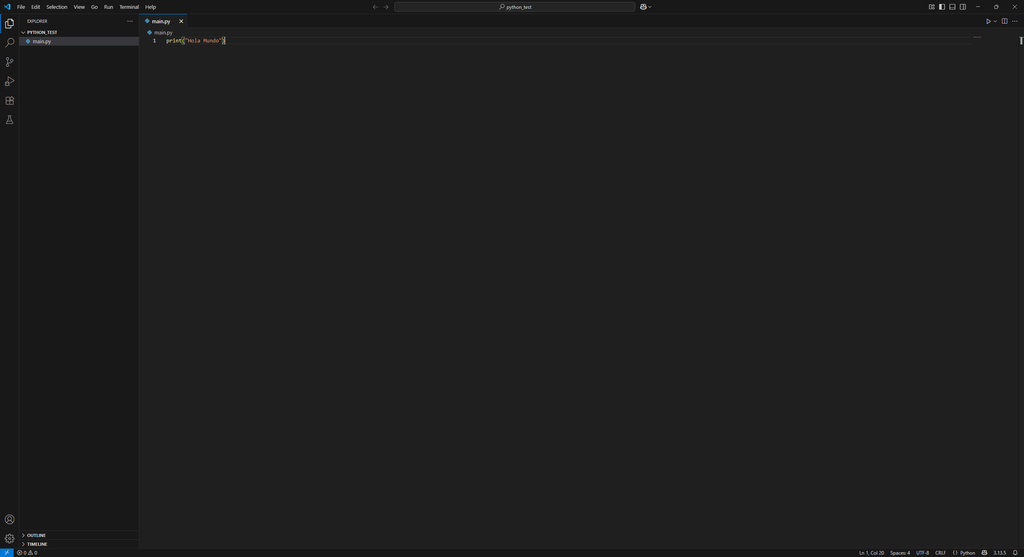

VSCode_Python

**Antes de ejecutar el codigo**, se creará un entorno de python para aislar la instalación de dependencias de paquetes. Dirijase a la parte superior del entorno y busque la opción `Show and run commands`.

[figure not shown]

VSCode_Python

Busque la opción `Python: Create Environment`.

[figure not shown]

VSCode_Python

Seleccione la opción `Venv`.

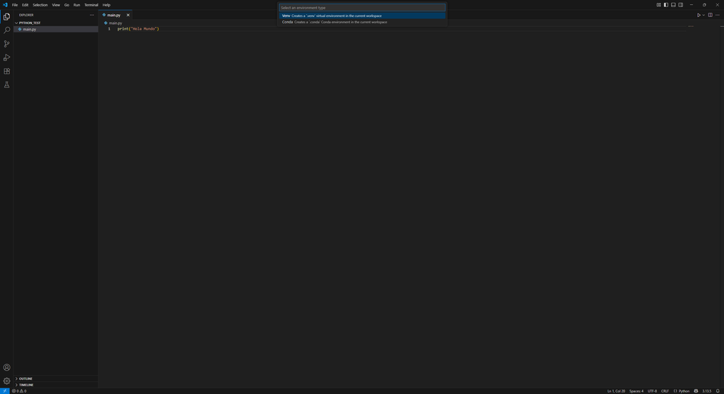

VSCode_Python

Seleccione la versión de python que tenga instalada en ese momento.

[figure not shown]

VSCode_Python

Se creará una carpeta con el entorno de python `.venv`. Ahora podemos proceder a ejecutar el código con este entorno.

[figure not shown]

VSCode_Python

Dirijase a la parte superior nuevamente, y busque la opción `Show and run commands`, luego `Python: Select Interpreter`

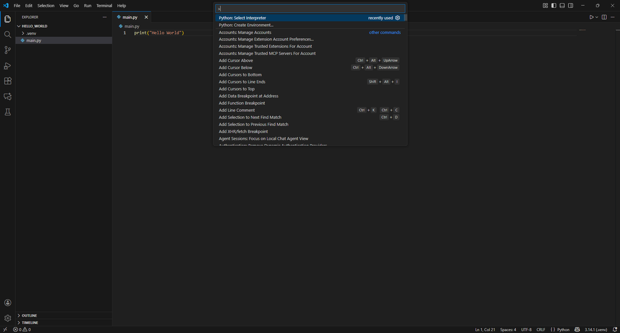

VSCode_Python

Seleccione la opcíón correspondiente al entorno que está en esta carpeta.

[figure not shown]

VSCode_Python

Finalmente, puede presionar sobre el botón `Run Python File` ubicado en la parte superior derecha. Se abrirá un terminal que muestra la ejecución del código, el interprete y el resultado de su codigo.

[figure not shown]

VSCode_Python

[figure not shown]

VSCode_Python